# Final Classification

Parker Kemp

May 2, 2019

## Classifying Spam Emails

### Introduction

The dataset that I have chosen for the classification portion of the final project is the Email Spam Data. The dataset consists of 57 numeric vectors, which are anonymous - details about the actual information contained in these vectors is not given, and a ‘spam’ variable - a factor with two levels, “email” and “spam”.

My goal is to use the provided variables to accurately identify messages as either “email” or “spam”. I will use several methods of classification to achieve this task, namely: Random Forests, Logistic Regression, K-Nearest Neighbors, and Linear Discriminant Analysis.

### Random Forest

```r
library(ElemStatLearn)
```

```r
data <- spam

head(data)
```

```
##    A.1  A.2  A.3 A.4  A.5  A.6  A.7  A.8  A.9 A.10 A.11 A.12 A.13 A.14
## 1 0.00 0.64 0.64   0 0.32 0.00 0.00 0.00 0.00 0.00 0.00 0.64 0.00 0.00
## 2 0.21 0.28 0.50   0 0.14 0.28 0.21 0.07 0.00 0.94 0.21 0.79 0.65 0.21
## 3 0.06 0.00 0.71   0 1.23 0.19 0.19 0.12 0.64 0.25 0.38 0.45 0.12 0.00
## 4 0.00 0.00 0.00   0 0.63 0.00 0.31 0.63 0.31 0.63 0.31 0.31 0.31 0.00
## 5 0.00 0.00 0.00   0 0.63 0.00 0.31 0.63 0.31 0.63 0.31 0.31 0.31 0.00
## 6 0.00 0.00 0.00   0 1.85 0.00 0.00 1.85 0.00 0.00 0.00 0.00 0.00 0.00
##   A.15 A.16 A.17 A.18 A.19 A.20 A.21 A.22 A.23 A.24 A.25 A.26 A.27 A.28
## 1 0.00 0.32 0.00 1.29 1.93 0.00 0.96    0 0.00 0.00    0    0    0    0
## 2 0.14 0.14 0.07 0.28 3.47 0.00 1.59    0 0.43 0.43    0    0    0    0
## 3 1.75 0.06 0.06 1.03 1.36 0.32 0.51    0 1.16 0.06    0    0    0    0
## 4 0.00 0.31 0.00 0.00 3.18 0.00 0.31    0 0.00 0.00    0    0    0    0
## 5 0.00 0.31 0.00 0.00 3.18 0.00 0.31    0 0.00 0.00    0    0    0    0
## 6 0.00 0.00 0.00 0.00 0.00 0.00 0.00    0 0.00 0.00    0    0    0    0
##   A.29 A.30 A.31 A.32 A.33 A.34 A.35 A.36 A.37 A.38 A.39 A.40 A.41 A.42
```

[output cut: 20 more lines]

```r
#Split data into training and test set
train <- sample(1:nrow(data),  4601/2, replace = F)

data_train <- data[train,]
data_test <- data[-train,]
```

Taking a look at the data doesn’t provide much insight, since the variables are anonymous, so it would be difficult to manually identify variables to use in classification. I will attempt to use Random Forests to select the most important variables and use these variables in creating my other models.

```r
library(randomForest)
```

```r
set.seed(1234)

#Fit random forest model, using approximately the square root of the number of predictors
forest <- randomForest(spam ~  ., data = data_train, mtry  = round(sqrt(ncol(data) - 1)),
                       ntree = 500, importance = TRUE)

#Predict using the test set
pred1 <- predict(forest, newdata = data_test)

#Plot confusion matrix
table(pred1,data_test$spam)
```

```
##
## pred1   email spam
##   email  1336   80
##   spam     39  846
```

```r
#Output percent of correct predictions
mean(pred1 == data_test$spam)
```

```
## [1] 0.9482834
```

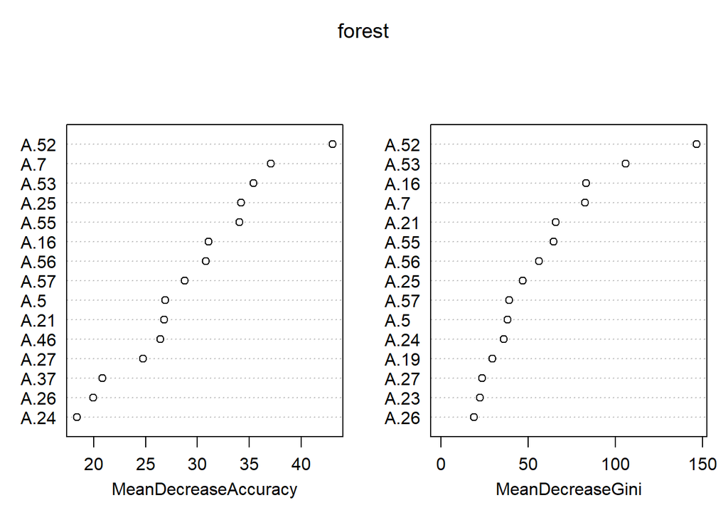

```r
#Plot the 10 most important variables
varImpPlot(forest, n.var = 15)
```

```r
set.seed(1234)
#Fit random forest model, using approximately the square root of the number of predictors
forest2 <- randomForest(spam ~  A.52 + A.53 + A.7 + A.16 + A.55 + A.21 + A.56 + A.25
                       +  A.24 + A.57 + A.5 + A.23 + A.27 + A.19 + A.26,
                       data = data_train, mtry  = 6,
                       ntree = 500)

#Predict using the test set
pred2 <- predict(forest2, newdata = data_test)

#Plot confusion matrix
table(pred2,data_test$spam)
```

```
##
## pred2   email spam
##   email  1316   87
##   spam     59  839
```

```r
#Output percent of correct predictions
mean(pred2 == data_test$spam)
```

```
## [1] 0.9365493
```

Using a smaller group of predictors with random forests doesn’t seem to improve the prediction accuracy at all. The ability to correctly predict spam emails was greater in the full model, but only by about 1%, so there is not a significant difference. However, this list of the most important predictors, and the fact that they provide nearly the same predictive power as the full dataset, will be useful in implementing the other classification methods, as I will be able to use a smaller set of predictors with confidence that they will provide nearly as good predictions as the full dataset would.

### K-Nearest Neighbors

```r
library(class)

#Data preparation for KNN algorithm
knn_train <- data_train[,c("A.52","A.53", "A.7", "A.16", "A.55", "A.21",
                           "A.56", "A.25", "A.24", "A.57", "A.5", "A.23",
                           "A.27","A.19","A.26")]

knn_test <- data_test[,c("A.52","A.53", "A.7", "A.16", "A.55", "A.21",
                           "A.56", "A.25", "A.24", "A.57", "A.5", "A.23",
                           "A.27","A.19","A.26")]

train_spam <- data_train$spam

#Transform data into a matrix to give to knn function
train_mat <- as.matrix(knn_train)
test_mat <- as.matrix(knn_test)

#Perform KNN with k=1
knn_pred <- knn(train_mat, test_mat, train_spam, k=1)

table(knn_pred,data_test$spam)
```

```
##
## knn_pred email spam
##    email  1170  265
##    spam    205  661
```

```r
#Set to 0 so that it will be overridden
max_acc <- 0

#Perform KNN classification with varying values of k, keep track of value that gives the greatest accuracy
for (i in 1:100){
  knn_pred <- knn(train_mat, test_mat, train_spam, k=i)
  acc <- mean(knn_pred == data_test$spam)

  if(acc > max_acc){
    max_acc <- acc
    k <- i
  }
}

sprintf("The maximum accuracy is %f, with k =  %i", max_acc, k)
```

```
## [1] "The maximum accuracy is 0.795741, with k =  1"
```

Using the subset of predictors I selected using random forests, the best accuracy achieved is 80% with k=1. This seems fairly low compared to the accuracy obtained with random forests, and the algorithm again had a higher miscalssification rate for spam compared to normal emails. This time, it misclassified nearly twice as many spam emails as not-spam (.28) than not-spam emails as spam (.15). In our case, identifying spam is the primary goal, so we would likely not want to use an algorithm that misclassifies our target category as frequently as this.

For all others values of k=2,…,100, the performance is worse than k=1, so it is not likely that we will be able to tune the KNN algorithm to perform well on this problem. Thus, we will move on to another classification method to see how it performs.

### Logistic Regression

Again perform classification using the predictors identified as being most important by the random forest, this time with logistic regression.

```r
logistic <- glm(spam ~ A.52 + A.53 + A.7 + A.16 + A.55 + A.21 + A.56 + A.25
                       +  A.24 + A.57 + A.5 + A.23 + A.27 + A.19 + A.26, data = data_train,
                family = binomial, maxit = 500)
summary(logistic)
```

```
##
## Call:
## glm(formula = spam ~ A.52 + A.53 + A.7 + A.16 + A.55 + A.21 +
##     A.56 + A.25 + A.24 + A.57 + A.5 + A.23 + A.27 + A.19 + A.26,
##     family = binomial, data = data_train, maxit = 500)
##
## Deviance Residuals:
##     Min       1Q   Median       3Q      Max
## -4.1584  -0.4828  -0.0002   0.1664   5.4376
##
## Coefficients:
##               Estimate Std. Error z value Pr(>|z|)
## (Intercept) -2.154e+00  1.444e-01 -14.921  < 2e-16 ***
## A.52         1.048e+00  1.733e-01   6.047 1.48e-09 ***
## A.53         4.772e+00  8.231e-01   5.798 6.72e-09 ***
## A.7          3.286e+00  5.027e-01   6.537 6.26e-11 ***
## A.16         1.202e+00  1.816e-01   6.619 3.63e-11 ***
## A.55        -2.333e-03  2.516e-02  -0.093 0.926118
## A.21         3.133e-01  5.791e-02   5.410 6.31e-08 ***
## A.56         1.196e-02  3.071e-03   3.896 9.79e-05 ***
## A.25        -2.298e+00  5.124e-01  -4.486 7.27e-06 ***
## A.24         4.660e-01  1.628e-01   2.863 0.004195 **
## A.57         6.748e-04  2.428e-04   2.779 0.005455 **
## A.5          5.528e-01  1.106e-01   4.997 5.81e-07 ***
## A.23         3.680e+00  7.784e-01   4.727 2.28e-06 ***
## A.27        -1.132e+01  3.270e+00  -3.461 0.000539 ***
## A.19         2.783e-02  4.226e-02   0.659 0.510179
## A.26        -7.095e-01  5.194e-01  -1.366 0.171908
## ---
## Signif. codes:  0 '***' 0.001 '**' 0.01 '*' 0.05 '.' 0.1 ' ' 1
##
## (Dispersion parameter for binomial family taken to be 1)
##
##     Null deviance: 3067.1  on 2299  degrees of freedom
## Residual deviance: 1182.5  on 2284  degrees of freedom
## AIC: 1214.5
##
## Number of Fisher Scoring iterations: 12
```

Logistic regression identifies almost all of the variables used in the model as significant, with a few exceptions. This gives some reassurance that the variables selected as important by the initial random forests algorithm are a good set of predictors to be used in this model.

```r
#Predict probabilities using test data
prob <- predict(logistic, new_data = data_test, type = "response")

#Assign observations to classes based on predicted probabilities
pred <- rep("spam", length(prob))
pred[prob < .5] <- "email"

#Print confusion matrix
table(pred, data_test[-2301,]$spam)
```

```
##
## pred    email spam
##   email   891  588
##   spam    483  338
```

```r
#Compute correct classification rate
mean(pred == data_test[-2301,]$spam)
```

```
## [1] 0.5343478
```

```r
logistic2 <- glm(spam ~ ., data = data_train,
                family = binomial, maxit = 500)
#Predict probabilities using test data
prob2 <- predict(logistic2, new_data = data_test, type = "response")

#Assign observations to classes based on predicted probabilities
pred2 <- rep("spam", length(prob))
pred2[prob2 < .5] <- "email"

#Print confusion matrix
table(pred2, data_test[-2301,]$spam)
```

```
##
## pred2   email spam
##   email   863  574
##   spam    511  352
```

```r
#Compute correct classification rate
mean(pred2 == data_test[-2301,]$spam)
```

```
## [1] 0.5282609
```

Using all predictors, logistic regression only gives an accuracy .52, roughly the same as when using a subset of predictors. Since this is not comparable to the accuracy of the random forest, logistic regression is not a good choice to use for this problem. Although it did not give good predictive results, logsitic regression helped to identify which variables were significant and confirm that many of the variables I chose using the random forest were in fact important to be included in the model.

### Linear Discriminant Analysis

```r
library(MASS)

#Perform lda using all variables
lda.fit <- lda(spam ~ ., data = data_train)

#Predict using test set
lda.pred <- predict(lda.fit, data_test)

#Print confusion matrix
table(lda.pred$class, data_test$spam)
```

```
##
##         email spam
##   email  1312  180
##   spam     63  746
```

```r
#Compute classificaition rate
mean(lda.pred$class == data_test$spam)
```

```
## [1] 0.8943937
```

LDA, using all predictors, gives an accuracy of .89, which is significantly better than logistic regression, but not quite as good as a random forest. Plotting the lda histograms, we can see the class division, and see that there is some overlap near zero between the two classes, but in general they are split into two distinct groups.

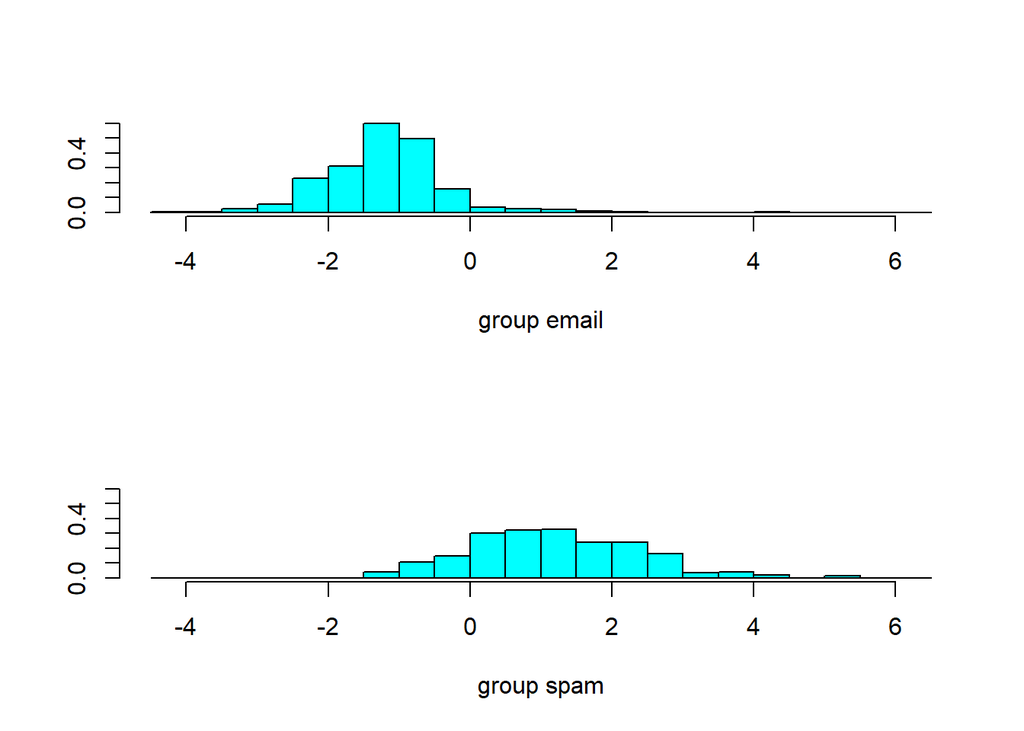

```r
plot(lda.fit)
```

### Summary and Discussion

The best classification accuracy was given by the random forest, with an accruacy of nearly 95%. LDA gave the second best accuracy of 89%, followed by KNN with k=1 at around 80%. Logistic regression performed the worst by a good margin, just barely outperforming the naive approach of random guessing.

Selecting which predictors to use for this task was a challenge, as the variables are not labeled, so we do not know what the data is actually recording or measuring. I did my best to identify which variables to use using a random forest to identify those most important, many of which were also deemed significant by the logistic regression model.

### References

Kjetil B. Halvorsen (2019). ElemStatLearn: Data Sets, Functions and Examples from the Book: “The Elements of Statistical Learning, Data Mining, Inference, and Prediction” by Trevor Hastie, Robert Tibshirani and Jerome Friedman. R package version 2015.6.26.1. https://CRAN.R-project.org/package=ElemStatLearn

James, Gareth, et al. An Introduction to Statistical Learning: With Applications in R. Springer, 2017.

Hastie, Trevor, et al. The Elements of Statistical Learning: Data Mining, Inference, and Prediction. Springer, 2004.